# mapping_HW

## Q1

- Do a world map.
- Show and label five places you want to travel to
- use an excel file to load your five places.
- turn in your excel file with the notebook
- turn in a jpeg of your map

Read in the data from excel

make the map

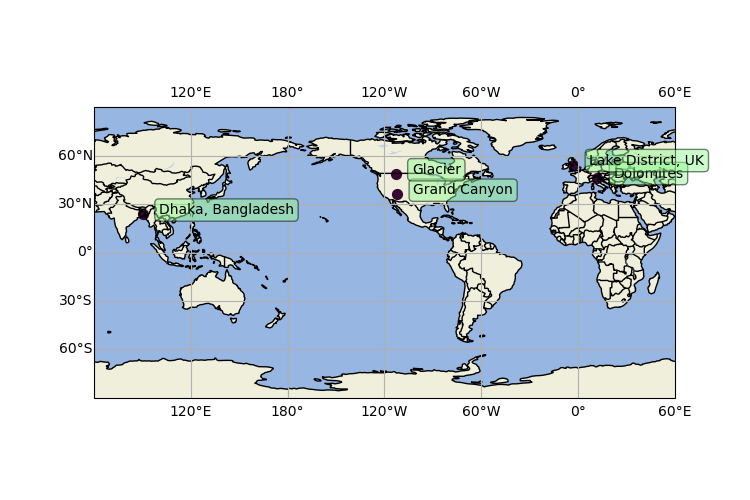

## Q2

- Surface temperatures on the day we were born
- Use the file you downloaded in class
- Want nice temperature intervals (whole numbers)
- A big symbol where you were born
- The date converted from the file as a title with day of the week
- Save the figure and send it to someone who might enjoy the data
- turn in the jpeg also

Read the netCDF file

Set the varaiables

Convert Air temperatures

```
Conversion Done!
```

Make the map

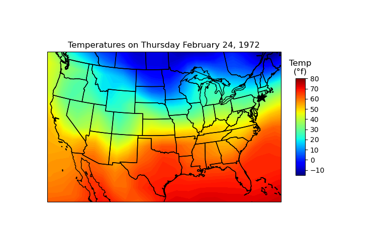

# Q3 - Final 10%

- In Folium choose a place you want to travel to
- Make a map labeling 5 places you want to visit there
- Store the five places in a second tab in your excel sheet.
- Read in the excel sheet and map them
- Upload the html file you make

Read in the data from excel

make the map

Make this Notebook Trusted to load map: File -> Trust Notebook

[interactive chart not shown]

[output not shown]